# The Airbnb Case: Regression, Partial Solution

MKT 566 · Decision Making Using Marketing Analytics · Fall 2026

**Name and USC ID:** ______

This is the Airbnb case with the coding already done. Every figure and every table is below, produced by the code shown above it. You write no code: this file is also your report.

Your job is the part the investor actually pays for: **the reading**. For each task, answer the questions in plain English, with the number that supports each claim, in the **My answers:** block under the questions. Then write the recommendation (Task 8) and turn your findings into a short presentation.

The client is an **investor** deciding where, and what kind of property, to buy and list on Airbnb. Every task builds toward your recommendation.

Using your AI assistant to talk through a table is fine, and a good idea. The sentences and slides you submit must be your own reading.

## How to work on it

1. Download the [R Markdown source of this page](https://github.com/dadepro/mkt566/raw/main/w4/w4-airbnb-case-partial.Rmd) (right-click, Save Link As…) and the [data](https://github.com/dadepro/mkt566/raw/main/w4/airbnb-case-data.zip). Put `w4-airbnb-case-partial.Rmd` and the unzipped `airbnb.csv` in the same folder, and open that folder in VS Code.
2. Fill in every **My answers:** block, and your name above.
3. Knit to HTML with the play button and check that every figure and table is visible in the knitted file. If knitting fails with “there is no package called ‘stargazer’”, run `install.packages("stargazer")` once in the R terminal.

## Reading a regression table: the checklist

Thursday’s lecture in four lines. Use it on every table below:

1. **Size**: one more unit of $X$ goes with how many units (or what percent) of $Y$? Say it in dollars.
2. **Stars**: is the coefficient distinguishable from zero? With 50,000 rows, almost everything is. That is not the interesting part.
3. **R-squared**: how much of the variation in $Y$ does the model explain?
4. **Base level**: for a categorical variable, every coefficient is a difference from the group that is missing from the table.

## The data

One row per **listing**. Columns:

| Column | What it is |
| --- | --- |
| `listing_id` | the listing |
| `price` | nightly price in dollars |
| `bedrooms`, `bathrooms` | number of bedrooms and bathrooms |
| `guests_included` | guests included in the price |
| `star_rating` | average rating, 1 to 5 |
| `reviews_count` | number of reviews the listing has |
| `city` | Austin, Boston, Los Angeles, Miami |
| `room_type` | Entire home, Private room, Shared room |
| `property_type`, `cancellation_policy`, `zipcode` | more details, not needed today |

## Task 1: look at the data

First look: the size of the data, prices, reviews, and where the listings are.

```r
airbnb <- fread("airbnb.csv")
head(airbnb)
```

```
##    listing_id price bathrooms bedrooms cancellation_policy guests_included
##         <int> <int>     <num>    <int>              <char>           <int>
## 1:        147   238         1        2              strict               4
## 2:       1078    89         1        1            flexible               2
## 3:       2055    89         1        1            moderate               1
## 4:       2265   175         2        2              strict               2
## 5:       3021   120         1        1              strict               2
## 6:       3319   119         1        1              strict               1
##    property_type zipcode star_rating reviews_count        city    room_type
##           <char>  <char>       <num>         <int>      <char>       <char>
## 1:         House   90291         5.0            79 Los Angeles  Entire home
## 2:     Apartment   78705         5.0           117      Austin  Entire home
## 3:         House   33145         5.0            91       Miami Private room
## 4:         House   78702         4.5            15      Austin  Entire home
## 5:         House   90046         4.5             4 Los Angeles  Entire home
## 6:     Apartment   90048         5.0           298 Los Angeles  Entire home
```

```r
nrow(airbnb); ncol(airbnb)
```

```
## [1] 50818
```

```
## [1] 12
```

```r
summary(airbnb$price)
```

```
##    Min. 1st Qu.  Median    Mean 3rd Qu.    Max.
##     1.0    69.0   100.0   142.4   165.0 10000.0
```

```r
summary(airbnb$reviews_count)
```

```
##    Min. 1st Qu.  Median    Mean 3rd Qu.    Max.
##    3.00    5.00    8.00   16.27   18.00  392.00
```

```r
table(airbnb$city)
```

```
##
##      Austin      Boston Los Angeles       Miami
##       10311        6147       27611        6749
```

```r
table(airbnb$room_type)
```

```
##
##  Entire home Private room  Shared room
##        32513        15829         2476
```

**Questions:**

- How many rows and columns? What does one row represent?
- Median and mean price: which is larger, and what does that tell you about the shape of the distribution? (Remember week 2.)
- How many listings are in each city? One city has more listings than the other three combined. Which one, and what does that mean for any claim you make about “Airbnb” as a whole?

**My answers:**

## Task 2: three pictures of the same relationship

On Thursday, price against the number of reviews was a cloud with no line in it. Here it is again, three ways: raw, with price logged, and with both logged.

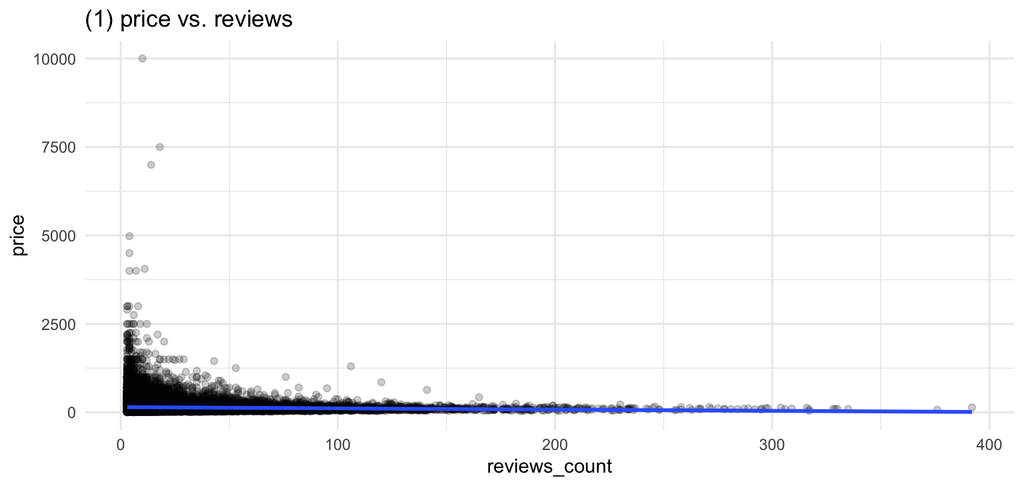

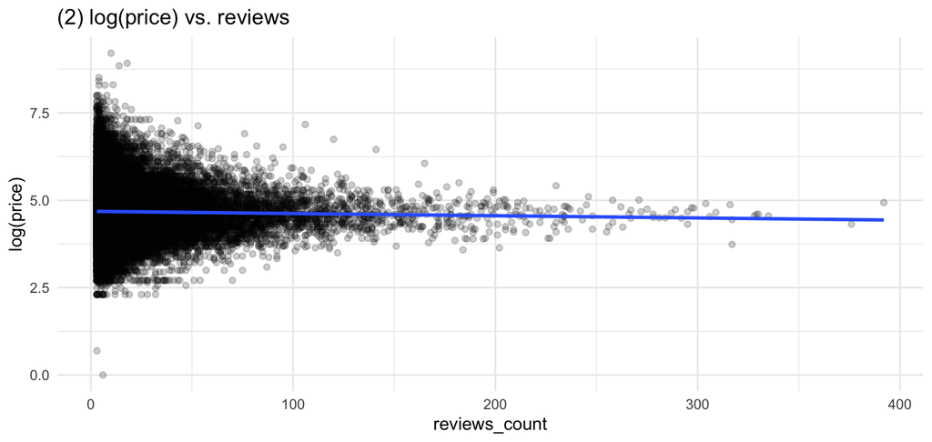

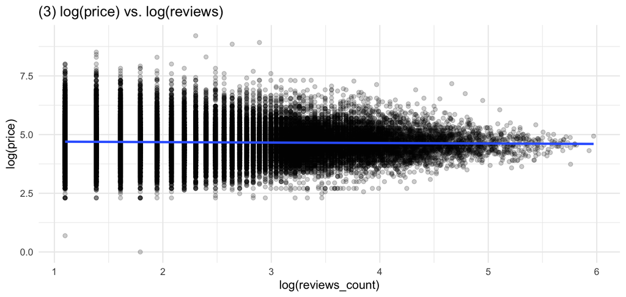

```r
p1 <- ggplot(airbnb, aes(reviews_count, price)) +
  geom_point(alpha = 0.2) + geom_smooth(method = "lm", se = FALSE) +
  labs(title = "(1) price vs. reviews") + theme_minimal()
p2 <- ggplot(airbnb, aes(reviews_count, log(price))) +
  geom_point(alpha = 0.2) + geom_smooth(method = "lm", se = FALSE) +
  labs(title = "(2) log(price) vs. reviews") + theme_minimal()
p3 <- ggplot(airbnb, aes(log(reviews_count), log(price))) +
  geom_point(alpha = 0.2) + geom_smooth(method = "lm", se = FALSE) +
  labs(title = "(3) log(price) vs. log(reviews)") + theme_minimal()
p1; p2; p3
```

**Questions:**

- Describe what changes from chart (1) to (2) to (3). Where did the $10,000 listings go in chart (2)?
- In which chart does a straight line make the most sense? Why did logging help?

**My answers:**

## Task 3: the three models

The regressions that go with the three charts, side by side.

```r
m1 <- lm(price ~ reviews_count, data = airbnb)
m2 <- lm(log(price) ~ reviews_count, data = airbnb)
m3 <- lm(log(price) ~ log(reviews_count), data = airbnb)
stargazer(m1, m2, m3, type = "text",
          column.labels = c("level-level", "log-level", "log-log"),
          omit.stat = c("f", "ser", "adj.rsq"), digits = 4, no.space = TRUE)
```

```
##
## ====================================================
##                           Dependent variable:
##                    ---------------------------------
##                       price         log(price)
##                    level-level log-level   log-log
##                        (1)        (2)        (3)
## ----------------------------------------------------
## reviews_count      -0.3475***  -0.0006***
##                     (0.0320)    (0.0001)
## log(reviews_count)                        -0.0194***
##                                            (0.0034)
## Constant           148.0541*** 4.6846***  4.7185***
##                     (0.9013)    (0.0038)   (0.0083)
## ----------------------------------------------------
## Observations         50,818      50,818     50,818
## R2                   0.0023      0.0004     0.0006
## ====================================================
## Note:                    *p<0.1; **p<0.05; ***p<0.01
```

**Questions:**

- Interpret the coefficient on `reviews_count` in each model, in one sentence each, with the right units: dollars per review, percent per review, or percent per percent. (Thursday’s functional-forms table.)
- What are the three R-squared values? Are they good, bad, or beside the point? What do they say about how much reviews tell you about price?
- All three coefficients have three stars. Does that mean reviews matter a lot for price?

**My answers:**

## Task 4: more predictors

Reviews alone explain almost nothing. Add what an investor would actually look at: rating, bathrooms, bedrooms, and guests included.

```r
m4 <- lm(price ~ reviews_count + star_rating + bathrooms + bedrooms + guests_included,
         data = airbnb)
stargazer(m4, type = "text", omit.stat = c("f", "ser", "adj.rsq"), digits = 3, no.space = TRUE)
```

```
##
## ===========================================
##                     Dependent variable:
##                 ---------------------------
##                            price
## -------------------------------------------
## reviews_count            -0.181***
##                           (0.027)
## star_rating              19.356***
##                           (1.490)
## bathrooms                62.542***
##                           (1.233)
## bedrooms                 57.747***
##                           (0.937)
## guests_included          12.312***
##                           (0.453)
## Constant                -124.536***
##                           (7.145)
## -------------------------------------------
## Observations              50,557
## R2                         0.329
## ===========================================
## Note:           *p<0.1; **p<0.05; ***p<0.01
```

**Questions:**

- Walk through the coefficients: one sentence each, in dollars, “holding the others fixed”. Do the signs make sense? Any surprise?
- What happened to the R-squared compared with Task 3? What does that tell you about which variables matter for price?
- The number of observations is a little smaller than in Task 3. Why? (What does `lm()` do with rows that have a missing value?)

**My answers:**

## Task 5: where is it expensive? City as a categorical variable

Add `city` to the Task 4 model. Then the check: the same model with dummy variables built by hand, leaving Austin out.

```r
m5 <- lm(price ~ reviews_count + star_rating + bathrooms + bedrooms + guests_included + city,
         data = airbnb)
airbnb[, austin := as.integer(city == "Austin")]
airbnb[, boston := as.integer(city == "Boston")]
airbnb[, la     := as.integer(city == "Los Angeles")]
airbnb[, miami  := as.integer(city == "Miami")]
m5b <- lm(price ~ reviews_count + star_rating + bathrooms + bedrooms + guests_included +
            boston + la + miami, data = airbnb)
stargazer(m5, m5b, type = "text", column.labels = c("factor", "dummies by hand"),
          omit.stat = c("f", "ser", "adj.rsq"), digits = 3, no.space = TRUE)
```

```
##
## ============================================
##                     Dependent variable:
##                 ----------------------------
##                            price
##                    factor    dummies by hand
##                     (1)            (2)
## --------------------------------------------
## reviews_count    -0.193***      -0.193***
##                   (0.027)        (0.027)
## star_rating      19.669***      19.669***
##                   (1.494)        (1.494)
## bathrooms        64.288***      64.288***
##                   (1.235)        (1.235)
## bedrooms         56.509***      56.509***
##                   (0.944)        (0.944)
## guests_included  12.615***      12.615***
##                   (0.452)        (0.452)
## cityBoston       22.303***
##                   (2.220)
## cityLos Angeles  -7.235***
##                   (1.599)
## cityMiami        -18.060***
##                   (2.146)
## boston                          22.303***
##                                  (2.220)
## la                              -7.235***
##                                  (1.599)
## miami                          -18.060***
##                                  (2.146)
## Constant        -123.412***    -123.412***
##                   (7.420)        (7.420)
## --------------------------------------------
## Observations       50,557        50,557
## R2                 0.334          0.334
## ============================================
## Note:            *p<0.1; **p<0.05; ***p<0.01
```

**Questions:**

- How many city coefficients do you get, and why not four? What is the base level, and what does the constant now mean?
- Interpret the city coefficients: which city is the most expensive and which the least, for a listing of the same size and rating? By how many dollars?
- Compare the factor version with the hand-made dummies. Same numbers? What does that tell you about what `lm()` does with a text column?

**My answers:**

## Task 6: from price to revenue

An investor cares about revenue, not the nightly price. We do not observe bookings, but reviews are a rough trace of them, so define `revenue = price * reviews_count` (a crude proxy; it returns in Task 8). First with `city`, then adding `room_type`. Notice that `reviews_count` is not in these models; the first question asks why.

```r
airbnb[, revenue := price * reviews_count]
summary(airbnb$revenue)
```

```
##    Min. 1st Qu.  Median    Mean 3rd Qu.    Max.
##       6     450     979    2132    2250  137800
```

```r
m6  <- lm(revenue ~ star_rating + bathrooms + bedrooms + guests_included + city, data = airbnb)
m6b <- lm(revenue ~ star_rating + bathrooms + bedrooms + guests_included + city + room_type,
          data = airbnb)
stargazer(m6, m6b, type = "text", column.labels = c("city", "city + room type"),
          omit.stat = c("f", "ser", "adj.rsq"), digits = 2, no.space = TRUE)
```

```
##
## ===================================================
##                            Dependent variable:
##                       -----------------------------
##                                  revenue
##                           city     city + room type
##                           (1)            (2)
## ---------------------------------------------------
## star_rating            684.24***      628.12***
##                         (38.38)        (38.19)
## bathrooms              284.90***      382.31***
##                         (31.76)        (31.87)
## bedrooms               576.48***      472.28***
##                         (24.26)        (24.25)
## guests_included        354.51***      275.60***
##                         (11.61)        (11.75)
## cityBoston             663.77***      697.07***
##                         (57.11)        (56.56)
## cityLos Angeles        228.00***      242.20***
##                         (41.14)        (40.76)
## cityMiami              -463.83***     -415.21***
##                         (55.20)        (54.66)
## room_typePrivate room                 -955.74***
##                                        (35.19)
## room_typeShared room                 -1,670.07***
##                                        (74.85)
## Constant              -3,001.25***   -2,226.36***
##                         (190.92)       (190.63)
## ---------------------------------------------------
## Observations             50,557         50,557
## R2                        0.09           0.11
## ===================================================
## Note:                   *p<0.1; **p<0.05; ***p<0.01
```

**Questions:**

- Why must `reviews_count` be dropped from a model of `price * reviews_count`?
- Which city has the highest revenue coefficient? Is it significant? Which is the highest **significant** one? Where would you buy, based on this table alone?
- Interpret the `room_type` coefficients: what is the base level, and how much less revenue does a private room or a shared room generate, holding the rest fixed?
- Did the city coefficients change when `room_type` came in? What would explain a change?

**My answers:**

## Task 7: does quality pay?

Create `highQuality` = 1 if the rating is 4.5 or higher, 0 otherwise, and put it in place of `star_rating` in the last Task 6 model. The table shows both versions side by side.

```r
airbnb[, highQuality := as.integer(star_rating >= 4.5)]
mean(airbnb$highQuality)
```

```
## [1] 0.899878
```

```r
m7 <- lm(revenue ~ highQuality + bathrooms + bedrooms + guests_included + city + room_type,
         data = airbnb)
stargazer(m6b, m7, type = "text", column.labels = c("star rating", "high-quality dummy"),
          omit.stat = c("f", "ser", "adj.rsq"), digits = 2, no.space = TRUE)
```

```
##
## =====================================================
##                             Dependent variable:
##                       -------------------------------
##                                   revenue
##                       star rating  high-quality dummy
##                           (1)             (2)
## -----------------------------------------------------
## star_rating            628.12***
##                         (38.19)
## highQuality                            904.40***
##                                         (51.74)
## bathrooms              382.31***       383.80***
##                         (31.87)         (31.86)
## bedrooms               472.28***       474.03***
##                         (24.25)         (24.24)
## guests_included        275.60***       275.57***
##                         (11.75)         (11.75)
## cityBoston             697.07***       671.33***
##                         (56.56)         (56.39)
## cityLos Angeles        242.20***       225.42***
##                         (40.76)         (40.65)
## cityMiami              -415.21***      -433.08***
##                         (54.66)         (54.56)
## room_typePrivate room  -955.74***      -949.18***
##                         (35.19)         (35.18)
## room_typeShared room  -1,670.07***    -1,678.81***
##                         (74.85)         (74.73)
## Constant              -2,226.36***       -68.89
##                         (190.63)        (71.53)
## -----------------------------------------------------
## Observations             50,557          50,557
## R2                        0.11            0.11
## =====================================================
## Note:                     *p<0.1; **p<0.05; ***p<0.01
```

**Questions:**

- What share of listings has `highQuality = 1`? (The `mean()` line above the table is that share.) Is 4.5 a demanding cutoff on this platform?
- Interpret the `highQuality` coefficient in one sentence, in dollars of revenue.
- Compare with the `star_rating` coefficient from Task 6: why are the two numbers not directly comparable? (What is “one unit” of each?)
- Is quality a big deal for revenue on Airbnb, according to this model? Give one reason the coefficient might overstate it and one reason it might understate it.

**My answers:**

## Task 8: the recommendation

You are advising the investor on **where to buy and what to list**. Write **three recommendations**, each one sentence plus the coefficient (with units) that supports it, naming the task and table it comes from. One of the three must state a **limitation** of this analysis for the decision. Two candidates: what `price * reviews_count` misses about revenue (does every guest leave a review? is the listed price the price paid? does a listing with 300 reviews earn that every year?), and what a regression on listings that *exist* cannot tell you about a property that does not yet exist.

**My recommendations:**

## The presentation

Turn your findings into a deck for the investor: **5 to 7 slides**.

1. **One slide**: the question and the data, one sentence each.
2. **Two or three slides**: your key findings. One finding per slide, stated as a full sentence with the number, its units, and the table it comes from. A chart or a cropped table per slide is fine; code is not.
3. **One slide**: the recommendation, where to buy and what to list.
4. **One slide**: the limitation, and what data you would want next.

The test for every slide: could the investor, who has not seen this handout, read it in ten seconds and repeat the point?